# Beyond Latency: A Visual Guide to Live Subtitle Quality (6 Dimensions)

# Dimension 1: Mean Latency (muL)

**Mean latency** is the average delay between speech and when the subtitle appears. Lower is faster.

Think of this as: *How late am I, on average?*

```python
# Mean Latency videos
base = parse_srt(CLIPS_DIR / "base_subtitles.srt")
low = parse_srt(CLIPS_DIR / "dimension_1_mean_latency" / "low_latency.srt")
high = parse_srt(CLIPS_DIR / "dimension_1_mean_latency" / "high_latency.srt")

_, _, lat_low = compute_latencies(base, low, ref="start")
_, _, lat_high = compute_latencies(base, high, ref="start")

m_low = compute_metrics(lat_low)
m_high = compute_metrics(lat_high)

display_side_by_side_videos(
    "dimension_1_mean_latency",
    f"Low mean (mu={format_s(m_low['mean'])})",
    f"High mean (mu={format_s(m_high['mean'])})",
    "#2ca02c",
    "#d62728",
    "Notice how much later the right subtitles arrive on average."
)
```

Low mean (mu=1.57s)

[video not shown]

High mean (mu=8.64s)

[video not shown]

**Tip:** Notice how much later the right subtitles arrive on average.

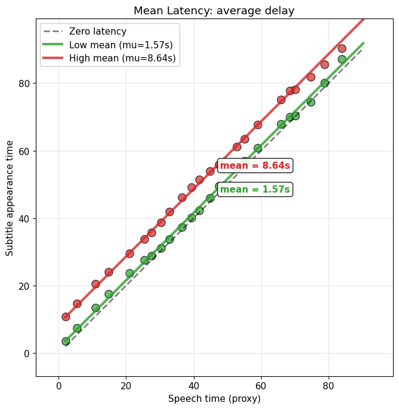

```
Key takeaways:
- Low mean: 1.57s
- High mean: 8.64s
- Difference: 7.07s
```

```python
# Mean Latency plot
base_times, low_times, lat_low = compute_latencies(base, low, ref="start")
_, high_times, lat_high = compute_latencies(base, high, ref="start")

plot_mean_latency(base_times, low_times, high_times, m_low, m_high)

print("Key takeaways:")
print(f"- Low mean: {format_s(m_low['mean'])}")
print(f"- High mean: {format_s(m_high['mean'])}")
print(f"- Difference: {format_s(m_high['mean'] - m_low['mean'])}")
```

# Dimension 2: Consistency (sigmaL)

**Consistency** tells us how much the delay varies from subtitle to subtitle.

Same average latency can feel very different if timing is unpredictable.

```python
# Consistency videos
base = parse_srt(CLIPS_DIR / "base_subtitles.srt")
low = parse_srt(CLIPS_DIR / "dimension_2_consistency" / "low_latency.srt")
high = parse_srt(CLIPS_DIR / "dimension_2_consistency" / "high_latency.srt")

_, _, lat_low = compute_latencies(base, low, ref="start")
_, _, lat_high = compute_latencies(base, high, ref="start")

m_low = compute_metrics(lat_low)
m_high = compute_metrics(lat_high)

display_side_by_side_videos(
    "dimension_2_consistency",
    f"High consistency (sigma={format_s(m_low['std'])})",
    f"Low consistency (sigma={format_s(m_high['std'])})",
    "#1f77b4",
    "#ff7f0e",
    "The right side feels jumpy because the delay is inconsistent."
)
```

High consistency (sigma=0.16s)

[video not shown]

Low consistency (sigma=2.57s)

[video not shown]

**Tip:** The right side feels jumpy because the delay is inconsistent.

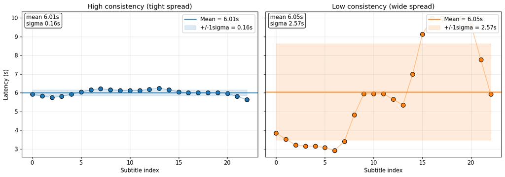

```
Key takeaways:
- High consistency sigma: 0.16s
- Low consistency sigma: 2.57s
- Same mean latency, very different predictability.
```

```python
# Consistency plot
plot_consistency(lat_low, lat_high)

print("Key takeaways:")
print(f"- High consistency sigma: {format_s(m_low['std'])}")
print(f"- Low consistency sigma: {format_s(m_high['std'])}")
print("- Same mean latency, very different predictability.")
```

# Dimension 3: Jitter (JL)

**Jitter** captures the **moment-to-moment jumps** in latency. Even if average and spread look similar, jitter can make the experience feel jerky.

Think of this as: *Do subtitles arrive in a smooth rhythm, or do they jump around?*

```python
# Jitter videos
base = parse_srt(CLIPS_DIR / "base_subtitles.srt")
low = parse_srt(CLIPS_DIR / "dimension_3_jitter" / "low_latency.srt")
high = parse_srt(CLIPS_DIR / "dimension_3_jitter" / "high_latency.srt")

_, _, lat_low = compute_latencies(base, low, ref="start")
_, _, lat_high = compute_latencies(base, high, ref="start")

m_low = compute_metrics(lat_low)
m_high = compute_metrics(lat_high)

display_side_by_side_videos(
    "dimension_3_jitter",
    f"Low jitter (JL={format_s(m_low['jitter'])})",
    f"High jitter (JL={format_s(m_high['jitter'])})",
    "#2ca02c",
    "#9467bd",
    "Look for sudden jumps in how late subtitles appear."
)
```

Low jitter (JL=0.05s)

[video not shown]

High jitter (JL=0.15s)

[video not shown]

**Tip:** Look for sudden jumps in how late subtitles appear.

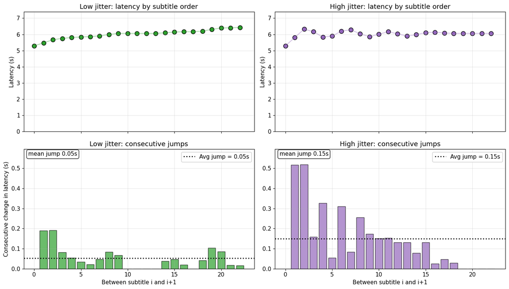

```
Key takeaways:
- Low jitter JL: 0.05s
- High jitter JL: 0.15s
- Jitter focuses on consecutive jumps, not overall spread.
```

```python
# Jitter plot
plot_jitter(lat_low, lat_high)

print("Key takeaways:")
print(f"- Low jitter JL: {format_s(m_low['jitter'])}")
print(f"- High jitter JL: {format_s(m_high['jitter'])}")
print("- Jitter focuses on consecutive jumps, not overall spread.")
```

# Dimension 4: Robustness (Rs)

**Robustness** measures how well timing holds up when speech speeds up.

Speech rate bands (from the paper):

- Normal: 100-160 WPM
- Elevated: 160-200 WPM
- Fast: >200 WPM

In this demo we show a **latency-only proxy** for Rs.

```python
# Robustness videos
base = parse_srt(CLIPS_DIR / "base_subtitles.srt")
low = parse_srt(CLIPS_DIR / "dimension_4_robustness" / "low_latency.srt")
high = parse_srt(CLIPS_DIR / "dimension_4_robustness" / "high_latency.srt")

_, _, lat_low = compute_latencies(base, low, ref="start")
_, _, lat_high = compute_latencies(base, high, ref="start")

display_side_by_side_videos(
    "dimension_4_robustness",
    "High robustness (quality holds under speed)",
    "Low robustness (falls behind when fast)",
    "#2ca02c",
    "#d62728",
    "Watch what happens when speech speeds up.",
    left_variant="high",
    right_variant="low"
)
```

High robustness (quality holds under speed)

[video not shown]

Low robustness (falls behind when fast)

[video not shown]

**Tip:** Watch what happens when speech speeds up.

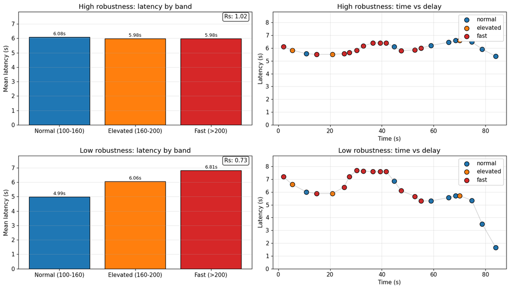

```
Key takeaways:
- High robustness keeps latency similar across speech rates.
- Low robustness falls behind during fast speech.
```

```python
# Robustness plot
plot_robustness(base, lat_low, lat_high)

print("Key takeaways:")
print("- High robustness keeps latency similar across speech rates.")
print("- Low robustness falls behind during fast speech.")
```

# Dimension 5: Degradation Mode (D)

**Degradation mode** describes *how* a system fails under stress:

- **Latency degradation**: accuracy stays good but subtitles arrive late
- **Accuracy degradation**: timing stays good but errors increase
- **Both degrade**: late and wrong

This dimension is **categorical**, not numeric, and is often the easiest for stakeholders to describe.

[figure not shown]

| Mode | What you see | What it means |
| --- | --- | --- |
| **Latency degradation** | Subtitles accurate but increasingly late | System prioritizes correctness over speed |
| **Accuracy degradation** | Timing good, but more errors or omissions | System prioritizes speed over accuracy |
| **Both degrade** | Late and error-prone at the same time | System is overwhelmed |

```python
# Degradation mode visual (conceptual)
plot_degradation_modes()

html = '''
<table style="width: 100%; border-collapse: collapse; font-size: 14px;">
  <tr>
    <th style="text-align: left; border-bottom: 2px solid #ccc; padding: 8px;">Mode</th>
    <th style="text-align: left; border-bottom: 2px solid #ccc; padding: 8px;">What you see</th>
    <th style="text-align: left; border-bottom: 2px solid #ccc; padding: 8px;">What it means</th>
  </tr>
  <tr>
    <td style="padding: 8px;"><strong>Latency degradation</strong></td>
    <td style="padding: 8px;">Subtitles accurate but increasingly late</td>
    <td style="padding: 8px;">System prioritizes correctness over speed</td>
  </tr>
  <tr>
    <td style="padding: 8px;"><strong>Accuracy degradation</strong></td>
    <td style="padding: 8px;">Timing good, but more errors or omissions</td>
    <td style="padding: 8px;">System prioritizes speed over accuracy</td>
  </tr>
  <tr>
    <td style="padding: 8px;"><strong>Both degrade</strong></td>
    <td style="padding: 8px;">Late and error-prone at the same time</td>
    <td style="padding: 8px;">System is overwhelmed</td>
  </tr>
</table>
'''

display(HTML(html))
```

# Dimension 6: Worst-Case Latency (L95)

**Worst-case (L95)** is the 95th percentile of latency. It captures the "tail" -- the rare but painful moments.

Think of this as: *How bad does it get when things go wrong?*

```python
# Worst-case videos
base = parse_srt(CLIPS_DIR / "base_subtitles.srt")
low = parse_srt(CLIPS_DIR / "dimension_5_worst_case" / "low_latency.srt")
high = parse_srt(CLIPS_DIR / "dimension_5_worst_case" / "high_latency.srt")

_, _, lat_low = compute_latencies(base, low, ref="start")
_, _, lat_high = compute_latencies(base, high, ref="start")

m_low = compute_metrics(lat_low)
m_high = compute_metrics(lat_high)

display_side_by_side_videos(
    "dimension_5_worst_case",
    f"Low worst-case (L95={format_s(m_low['l95'])})",
    f"High worst-case (L95={format_s(m_high['l95'])})",
    "#2ca02c",
    "#d62728",
    "The right side has occasional very late subtitles."
)
```

Low worst-case (L95=6.34s)

[video not shown]

High worst-case (L95=11.03s)

[video not shown]

**Tip:** The right side has occasional very late subtitles.

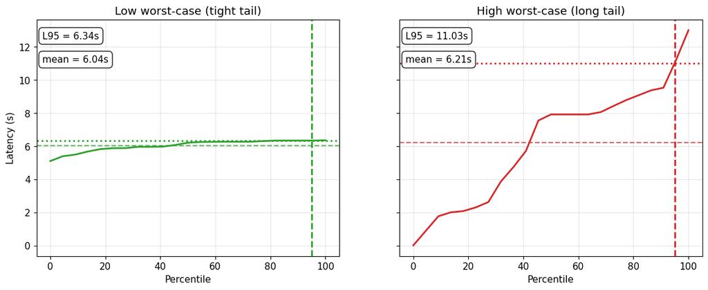

```
Key takeaways:
- Low L95: 6.34s
- High L95: 11.03s
- Worst-case shapes trust more than the average.
```

```python
# Worst-case plot
plot_worst_case(lat_low, lat_high)

print("Key takeaways:")
print(f"- Low L95: {format_s(m_low['l95'])}")
print(f"- High L95: {format_s(m_high['l95'])}")
print("- Worst-case shapes trust more than the average.")
```

# Putting it all together

The **Subtitle Temporal Quality Score (STQS)** combines the *numeric* dimensions into one score (weights from the paper):

```
STQS = 0.25*f(muL) + 0.30*g(sigmaL) + 0.15*h(JL) + 0.15*Rs + 0.15*k(L95)
```

**Note:** Degradation Mode (D) is **categorical**, so it is not folded into the numeric score.

```python
# Summary table (computed from demo clips)

def summarize_dimension(dim_key, label, good_variant="low", bad_variant="high"):
    base = parse_srt(CLIPS_DIR / "base_subtitles.srt")
    good = parse_srt(CLIPS_DIR / dim_key / f"{good_variant}_latency.srt")
    bad = parse_srt(CLIPS_DIR / dim_key / f"{bad_variant}_latency.srt")

    _, _, lat_good = compute_latencies(base, good, ref="start")
    _, _, lat_bad = compute_latencies(base, bad, ref="start")

    m_good = compute_metrics(lat_good)
    m_bad = compute_metrics(lat_bad)

    return {
        "Dimension": label,
        "Good (key metric)": None,
        "Bad (key metric)": None,
        "Notes": "",
    }, m_good, m_bad

rows = []

row, m_good, m_bad = summarize_dimension("dimension_1_mean_latency", "Mean Latency (muL)")
row["Good (key metric)"] = format_s(m_good["mean"])
row["Bad (key metric)"] = format_s(m_bad["mean"])
row["Notes"] = "Lower mean is better"
rows.append(row)

row, m_good, m_bad = summarize_dimension("dimension_2_consistency", "Consistency (sigmaL)")
row["Good (key metric)"] = format_s(m_good["std"])
row["Bad (key metric)"] = format_s(m_bad["std"])
row["Notes"] = "Lower sigma is more predictable"
rows.append(row)

row, m_good, m_bad = summarize_dimension("dimension_3_jitter", "Jitter (JL)")
row["Good (key metric)"] = format_s(m_good["jitter"])
row["Bad (key metric)"] = format_s(m_bad["jitter"])
row["Notes"] = "Lower JL = smoother rhythm"
rows.append(row)

row, m_bad, m_good = summarize_dimension("dimension_4_robustness", "Robustness (Rs)", good_variant="high", bad_variant="low")
row["Good (key metric)"] = "High robustness"
row["Bad (key metric)"] = "Low robustness"
row["Notes"] = "Shown as latency-only proxy"
rows.append(row)

rows.append({
    "Dimension": "Degradation Mode (D)",
    "Good (key metric)": "Latency OR accuracy holds",
    "Bad (key metric)": "Both degrade",
    "Notes": "Categorical; not in numeric STQS",
})

row, m_good, m_bad = summarize_dimension("dimension_5_worst_case", "Worst-Case (L95)")
row["Good (key metric)"] = format_s(m_good["l95"])
row["Bad (key metric)"] = format_s(m_bad["l95"])
row["Notes"] = "Lower L95 = tighter tail"
rows.append(row)

pd.DataFrame(rows)
```

|  | Dimension | Good (key metric) | Bad (key metric) | Notes |
| --- | --- | --- | --- | --- |
| 0 | Mean Latency (muL) | 1.57s | 8.64s | Lower mean is better |
| 1 | Consistency (sigmaL) | 0.16s | 2.57s | Lower sigma is more predictable |
| 2 | Jitter (JL) | 0.05s | 0.15s | Lower JL = smoother rhythm |
| 3 | Robustness (Rs) | High robustness | Low robustness | Shown as latency-only proxy |
| 4 | Degradation Mode (D) | Latency OR accuracy holds | Both degrade | Categorical; not in numeric STQS |
| 5 | Worst-Case (L95) | 6.34s | 11.03s | Lower L95 = tighter tail |